Eerste beweging · Verschil onder de loep

# Hoofdstuk 1 — De gemiddelde slok

Gemiddelde en standaardafwijking

> H1 opent met een korte slokjes-scène: olifant en meeuw bij het meer. Pointe: een “gemiddelde slok” smaakt niet — bij iets kwalitatiefs is een gemiddelde fictie. Maar bij meetbare dingen kan een gemiddelde wel, met de waarschuwing van de olifant op de schouder. Daarna het rekenwerk op de `diamantjes`-data (n=12; karaat × **glans**, besluit 5-7 — was prijs). De vondst-scène in §2 komt uit de schatkistje-splitsing (5-7); het vervolg van dat verhaal (terugkeer + kraai-diefstal) zit in H4.

## 1. Wat de meeuw zag

De meeuw stond op de rug van de olifant.

De olifant stond bij het meer en dronk.

“Ik heb mensen gezien,” zei de meeuw na een tijdje. “Laatst, vanaf een paaltje langs een wandelpad.”

De olifant dacht na, en dronk nog een keer.

“En?”

“Ze kijken. En dan beginnen ze te tellen. Hoe vaak iemand lacht in een gesprek. Hoeveel passen tot aan de boom. Hoe vaak iemand ‘ja’ zegt voordat hij eindelijk ‘nee’ durft.”

De olifant zweeg.

“Bij jou zouden ze de slokken tellen, denk ik. Hoeveel je drinkt op een dag. In hoeveel keer.”

“Tja. Voor wie?”

“Voor zichzelf, geloof ik.”

De olifant keek naar het water.

“En dan?” vroeg hij.

“Dan maken ze er één getal van. Eén slok. Een gemiddelde slok.”

De olifant dronk, langzaam dit keer.

“En hoe smaakt die?”

De meeuw dacht na.

“Niet.”

De olifant knikte. “Smaak ken ik alleen. Deze slok was modderig — ik ging iets te diep. De vorige was koud, helder. Daarvoor zoet, een streep regen die was binnengezwommen. Soms zilt, alsof er ergens zout op afstand zit. Geen slok smaakt als de andere. Een gemiddelde slok zou een slok zijn die nergens naar smaakt. En die heb ik nog nooit gehad.”

“Maar als ze het zouden willen schetsen?”

“Hoeveel water, ja. Hoe lang. Maar dan weten ze iets over al mijn slokken samen, en niets over één van mijn slokken apart. En als ze alleen dat weten, weten ze in elk geval dat ze mijn slokken niet kennen.”

De meeuw bleef even stil. “Dan zouden ze óók moeten weten hoe ver de echte slokken van die ene gemiddelde slok af staan.”

“Dan weten ze iets,” zei de olifant.

Wat de meeuw hier ziet, gebeurt vanzelf. Als je verschillen blijft zien — het ene meer dan het andere, het ene vaker dan het andere — komt vanzelf de vraag:

> *Wat is het midden?*

Dat is waar tellen overgaat in samenvatten. Waar losse waarnemingen één getal worden.

Eén ding meteen helder.

> *Een gemiddelde slok bestaat niet.*

Niet omdat het moeilijk is. Omdat er niets is om te proeven.

En toch — bij dingen die we kunnen meten — doen we het voortdurend. We nemen verschillen, en maken er één getal van. Een gemiddelde.

Vanaf hier hebben we taal nodig.

## 2. De diamantjes

Op een ochtend in september vond een bever iets in zijn dam.

Hij had al weken aan die dam gewerkt, met de tand-precisie waar bevers om bekend staan, en niet voor de eerste keer bleef er iets onverwachts in hangen — een tak, een vis, een schoen. Maar wat hij nu vond, was anders. Een houten kistje, niet veel groter dan zijn eigen kop, doorweekt en zwaar.

Hij sleepte het naar de oever en riep om hulp, want een bever opent houten dingen maar op één manier, en daar blijft weinig kistje van over. De olifant kwam aanlopen, had niets beters te doen die dag. De meeuw landde op een tak om te kijken. Een kraai kwam ook, want kraaien laten een schatkistje niet over aan andere dieren.

Ze openden het kistje samen. Erin lagen, op een laagje verbleekt fluweel, twaalf diamantjes.

“Mens-spul,” mompelde de bever.

“Verloren,” zei de olifant. “Lang geleden.”

Twaalf diamantjes. Allemaal anders. Geen twee dezelfde — net wat de meeuw beschreef.

Voor zover je ze kunt meten, kun je er een gemiddelde van maken. Voor zover je ze proeft, niet.

Uit de dam van een bever dus. Wij hebben ze mogen meten, op twee dingen: hun *karaat* (de gewichtsmaat voor edelstenen) en hun *glans* (hoe fel ze het licht teruggeven, gemeten met de glansmeter — een schaal van 0 tot 100). De diamantjes hebben namen — Anna, Bram, Cees, Dora, Else, Faas, Geer, Hans, Ida, Joop, Kees en Leen — die je vanzelf wel onthoudt, of niet, en dat is allebei prima.

*Karaat* (afgekort *ct*) is de gewichtsmaat voor edelstenen. 1 karaat = 0,2 gram = 200 milligram. Onze grootste diamantjes (Kees, Leen) zijn 1.5 karaat — 300 milligram, pakweg vijftien rijstkorrels bij elkaar. Alle twaalf samen wegen precies twaalf karaat: 2,4 gram — minder dan één suikerklontje. Diamanten worden klein gemeten, maar tellen zwaar.

**Tabel 1.1.** *De twaalf diamantjes met hun karaat (de gewichtsmaat voor edelstenen, 1 ct = 0,2 g) en glans (glansmeter, schaal 0–100).*

| *id* | *naam* | *karaat* | *glans (0–100)* |
| --- | --- | --- | --- |
| 1 | Anna | 0.4 | 20 |
| 2 | Bram | 0.5 | 30 |
| 3 | Cees | 0.5 | 30 |
| 4 | Dora | 0.7 | 30 |
| 5 | Else | 1.0 | 50 |
| 6 | Faas | 1.0 | 70 |
| 7 | Geer | 1.1 | 80 |
| 8 | Hans | 1.2 | 60 |
| 9 | Ida | 1.3 | 70 |
| 10 | Joop | 1.3 | 80 |
| 11 | Kees | 1.5 | 30 |
| 12 | Leen | 1.5 | 50 |

**score** *score*, *value*, *observation* ook: waarde, meting

Een korte aanwijzing voor wie nog niet vaak met data heeft gewerkt. Elke *rij* in de tabel — rijen lopen horizontaal, van links naar rechts — staat voor één *geval*: wat statistici een *case* of een *observatie* noemen, en wat bij ons één diamantje is. Elke *kolom* — verticaal, van boven naar beneden — staat voor één *eigenschap* die we van die gevallen hebben gemeten: een *variabele*. Wat in zo’n cel staat — bijvoorbeeld Anna’s *0.4* in de karaat-kolom — heet een *score* (in onderzoeksartikelen kom je dat woord constant tegen, ook bij dingen die je gewoon meet en niet “scoort”). De *id*-kolom geeft elk diamantje een rijnummer; de *naam*-kolom is voor de gezelligheid — diamantjes zijn niet anoniem, voor wie ze telt.

En nu je die tabel voor je hebt, kan ik je in één keer twee woordjes geven waar onderzoekers hun leven lang mee blijven rommelen. Ze staan namelijk gewoon in het tabelrooster.

Kolommen zijn variabelen. Rijen zijn diamantjes. Dus:

> **In** wijst een kolom aan. **Tussen** wijst rijen aan. *Er is verschil in glans tussen Anna en Kees.*

Meer is het niet. Verschil **in** karaat, verschil **in** glans — dat gaat over wát je gemeten hebt. Verschil **tussen** Anna en Kees, tussen de zware en de lichte — dat gaat over wíé je vergelijkt.

Zodra je die twee door elkaar haalt, gaat het mis, en dat gebeurt vaker dan je denkt. *“Het verschil tussen glans”* — tussen glans en wat? *“Het verschil in Anna en Kees”* — in hun karaat, hun glans, hun humeur? Dan weet de lezer niet meer waar de zin over gaat, en meestal weet de schrijver het zelf ook niet meer.

Het klinkt als muggenzifterij tot je een tabel als deze voor je hebt. Dan zie je dat er twee richtingen zijn — omlaag door een kolom, opzij langs een rij — en dat je voor elke richting een eigen voorzetsel nodig hebt.

Daar gaan we wat aan rekenen.

## 3. Van midden naar spreiding

### Het gemiddelde

**gemiddelde** *mean* ook: *expected value*, *M*

Hoe smaakt een gemiddeld diamantje? Niet, hopelijk. Maar hoe groot is een gemiddeld diamantje, en hoe glanzend — daar kunnen we wat over zeggen.

Het gemiddelde is wat je krijgt als je alle waarden bij elkaar optelt en deelt door hoe veel het er waren. In formule:

$$\overline{X} = \frac{\sum_{i=1}^{n} X_i}{n} \tag{1.1a}$$

Hoe je deze formule leest, stuk voor stuk:

- $\overline{X}$ — het gemiddelde van $X$. Het streepje boven de letter is je signaal: dit is een samenvatting, geen losse waarde.
- $\sum_{i=1}^{n}$ — het *sommatieteken* (de Griekse letter *sigma*). Hij zegt: *tel alles op wat erna komt, voor $i$ van 1 tot en met $n$*.
- $X_i$ — de waarde (score) van $X$ voor het $i$-de geval. $X_1$ is de eerste (Anna’s karaat), $X_2$ de tweede (Bram), …, $X_n$ de laatste (Leen).
- $n$ — het aantal gevallen. Bij ons: 12.

Lees als: *tel alle waarden op, en deel door hoeveel het er waren.*

We kunnen hetzelfde ook iets anders schrijven, en dat doen we met een reden:

$$\overline{X} = \frac{1}{n} \sum_{i=1}^{n} X_i \tag{1.1b}$$

Dezelfde berekening, andere notatie. In plaats van *delen door $n$* schrijven we het hier als *vermenigvuldigen met $\frac{1}{n}$*. Dat lijkt op een notatie-grapje, maar dat is het niet. Statistici denken graag in vermenigvuldigingen, en als we straks naar regressie, transformaties en verwachtingswaarden gaan, wordt vorm 1.1b handiger om mee te werken. Onthou dus dat 1.1a en 1.1b precies hetzelfde getal opleveren — alleen anders opgeschreven.

Voor onze twaalf diamantjes:

$$\begin{aligned}
\overline{X} &= \frac{0.4 + 0.5 + 0.5 + 0.7 + 1.0 + 1.0 + 1.1 + 1.2 + 1.3 + 1.3 + 1.5 + 1.5}{12} \\[0.4em]
&= \frac{12.0}{12} \\[0.4em]
&= 1.0
\end{aligned}$$

$$\begin{aligned}
\overline{Y} &= \frac{20 + 30 + 30 + 30 + 50 + 70 + 80 + 60 + 70 + 80 + 30 + 50}{12} \\[0.4em]
&= \frac{600}{12} \\[0.4em]
&= 50
\end{aligned}$$

In symbolen schrijven we het gemiddelde van een variabele $X$ als $\overline{X}$ (“X-streep”). In APA-rapportages, die je in artikelen tegenkomt, gebruikt men vaker een hoofdletter *M* — *M* van *mean*. Allebei mag, en je moet beide kunnen lezen. We zullen er nog van wisselen.

Wat is dat gemiddelde nu eigenlijk? Het is de “gemiddelde diamant” die de meeuw zou tekenen. Eentje van 1 karaat, glans 50. En nu moet ik iets bekennen dat de meeste boeken hier zouden verzwijgen: die diamant bestáát. Kijk maar in de tabel. **Else.** Eén karaat precies, glans precies 50 — tot op de komma de gemiddelde diamant, in levenden lijve. En zeg het er meteen eerlijk bij: dat is *toeval*. Bij de meeste groepen staat er op dat gemiddelde-kruispunt helemaal niemand — het had bij ons net zo goed leeg kunnen zijn. Maar bij ons woont er toevallig iemand, en dat toeval gaan we uitbuiten. Voor nu geldt gewoon: als je moet zeggen hoe fel een willekeurig diamantje uit deze groep glanst, en je hebt geen andere informatie, dan is het gemiddelde je beste gok. Daarom heet het ook wel de *verwachte waarde*, of het *nul-model*: het simpelste model dat we van deze werkelijkheid kunnen maken — twaalf diamantjes en hun *scores* op karaat en glans.

### Even iets over symbolen

Voor we verder rekenen, een korte aanwijzing over hoe je formules leest. Statistici zijn er nogal precies in, en ze hebben er een reden voor.

- **Hoofdletters** ($X$, $Y$) gebruiken we voor de *variabele zelf* — het hele lijstje karaat-waarden, of de hele kolom glans-waarden. Het concept, niet één geval.
- **Hoofdletters met een indexje** ($X_i$, $Y_i$) gebruiken we voor *één specifieke waarde*. Bijvoorbeeld $X_5 = 1.0$ is Else’s karaat (zij is de vijfde in de tabel), en $Y_{11} = 30$ is Kees’s glans. (In andere boeken zie je hiervoor ook wel kleine letters, $x_i$ — zelfde idee, andere huisstijl.)
- **Hoofdletters met een streepje** ($\overline{X}$, $\overline{Y}$) zijn het gemiddelde van een steekproef. Spreek uit als “X-streep” en “Y-streep”. In APA-stijl in lopende tekst zie je ook *M* (van *mean*) — beide bedoelen hetzelfde.
- **Griekse letters** ($\mu$, $\sigma$) reserveren we voor de *populatie* — de hele wereld waarvan we maar een steekproef hebben gemeten. *Mu* in plaats van *M*, *sigma* in plaats van *SD*. Daarop komen we in een later hoofdstuk terug.

Eén tussen-haakje, want het onderscheid is belangrijk. Een samenvattend getal van een *steekproef* heet een **statistiek** — $\overline{X}$, $S$, $SS$, allemaal wat we in dit hoofdstuk berekenen. Hetzelfde idee voor de hele *populatie* heet een **parameter** — $\mu$, $\sigma$. Een Levi’s 501 heeft ook *parameters*: taille 28, lengte 32. Die getalletjes beschrijven de échte jeans. *Statistieken* zijn schattingen van parameters, gemaakt op een steekproef. Daar komen we in een later hoofdstuk uitgebreid op terug — voor nu is het genoeg om de namen te kennen.

Als richtlijn: *hoofdletter = de variabele, indexje erbij = één observatie, streepje erboven = gemiddelde (statistiek), Grieks = populatie (parameter)*.

Zie je dat ook bij andere statistici? Ja. Hayes (van het *Mediation, Moderation* boek dat je in jaar 2 van je psychologie-bachelor of later tegenkomt) en Tabachnick & Fidell (de bijbel voor multivariate statistiek) houden zich aan dezelfde conventie. Soms zie je een hoofdletter $B$ voor een ongestandaardiseerde regressie-coëfficiënt en een Griekse $\beta$ (“beta”) voor de gestandaardiseerde — een verwarring waar we later mee leven, maar nu niet.

### De afwijking — hoe ver staat een diamant van zichzelf?

**residu** *residual* ook: individuele afwijking, *error*

Maar de olifant heeft gelijk. Niet elke diamant is dat gemiddelde. Laten we eens een spel spelen — *het grabbel-spel*.

Stel je voor: we leggen onze twaalf diamantjes terug in hun kistje, schudden het flink, en jij pakt er straks blind eentje uit. Wat is je beste gok voor zijn glans?

Het gemiddelde, natuurlijk — een glans van 50. Dat is je beste gok als je niets anders weet. Maar zodra je de getrokken diamant ziet, zie je hoe ver hij van je gok afzit. Boven of onder, links of rechts van het gemiddelde. Je trekt Anna: 20 in plaats van 50 — je hebt er 30 te hoog gegokt. Geer: 80 — 30 te laag. Kees: 30 — weer 20 te hoog gegokt, een doffe verrassing voor wie zijn karaat van 1.5 zag.

Het verschil tussen de echte waarde en je gok noemen we de *gokfout*. Soms positief, soms negatief. Boven of onder, links of rechts van het gemiddelde. We hebben er ook al formele namen voor — *afwijking*, *residu*, of *error*. Vier woorden voor hetzelfde.

Voor elke diamant kunnen we de gokfout uitrekenen — ook voor karaat, niet alleen voor glans. In formule:

$$\begin{aligned}
\text{residu} &= \text{observatie} - \text{verwachting} \\
&= X_i - \overline{X}
\end{aligned}$$

Voor Anna’s karaat: $0.4 - 1.0 = -0.6$. Voor Kees: $1.5 - 1.0 = 0.5$. Voor Else (1.0 karaat): $1.0 - 1.0 = 0$ — Else valt precies op het gemiddelde.

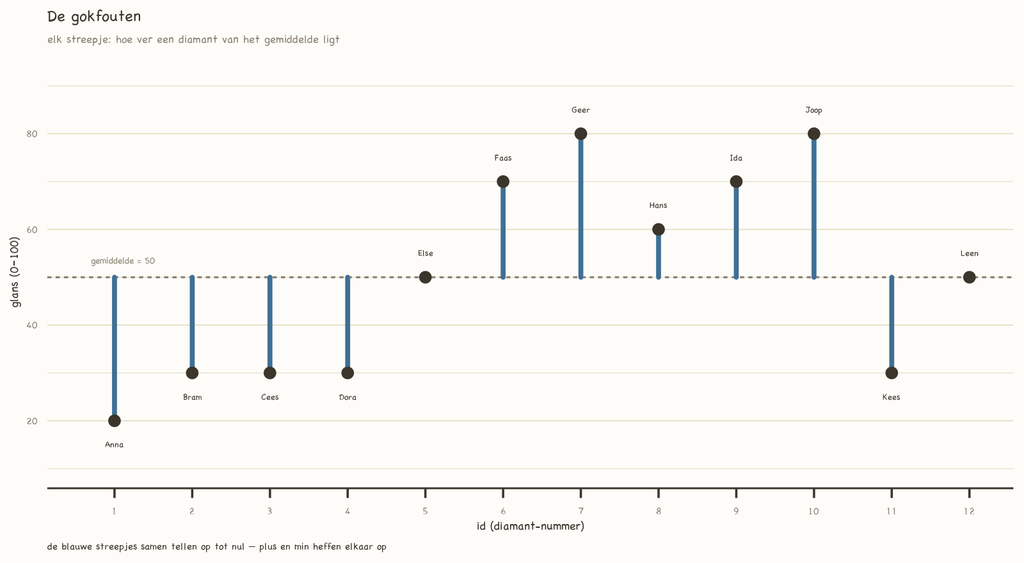

**Figuur 1.1** (streepjes) als warme boek-figuur (`_bouw_ontbrekend.R`, gedeelde `_stijl.R`); verving de inline ggplot-chunk — boek-lichaam software-vrij (R-besluit). Namen boven/onder, nooit door een streepje.

Een interessant ding: als je alle residuen optelt, krijg je nul. Niet bijna nul, niet ongeveer — exact nul. Probeer het maar. Dat is precies de reden dat we niet rechtstreeks het gemiddelde van de gewone residuen kunnen nemen — die uitkomst is altijd nul, geen reflectie van spreiding. En dat is geen toeval: het gemiddelde is per definitie het punt waar de afwijkingen elkaar in evenwicht houden. Wie boven het gemiddelde ligt, heeft een spiegelbeeld onder het gemiddelde. Anders zou het geen gemiddelde meer zijn.

Vervelend voor ons, want we wilden juist iets zeggen over hoe ver de diamantjes uit elkaar liggen. Als de afwijkingen elkaar opheffen, krijgen we daar nul voor terug. Een nul-spreiding. Dat is óók een halve waarheid — net wat de meeuw níét wilde.

### Kwadrateren — een kleine truc

*Kwadrateren* betekent: een getal vermenigvuldigen met zichzelf. $3^2 = 3 \times 3 = 9$. Voor een negatief getal: $(-3)^2 = (-3) \times (-3) = 9$ — een minteken keer een minteken geeft een plus, dus elke kwadraat is positief.

De oplossing is mooi simpel. We willen positieve én negatieve afwijkingen even hard meetellen, zonder dat ze elkaar opheffen. Dus kwadrateren we alle afwijkingen. Het kwadraat van een negatief getal is positief, en het kwadraat van een positief getal blijft positief. Het minteken verdwijnt.

Anna’s karaat-residu was $-0.6$. Kwadraat: $(-0.6)^2 = 0.36$. Kees: $(0.5)^2 = 0.25$. Else: $0^2 = 0$.

Als we alle gekwadrateerde residuen voor *karaat* optellen, krijgen we wat we de *kwadratensom* noemen, vaak afgekort als $SS$ (van *sum of squares*):

**kwadratensom** *sum of squares (SS)*

Het symbool $\sum$ heet *sigma* — Grieks voor de S, en hij komt van *som*. $\sum_{i=1}^{n} X_i$ betekent: tel alle waarden $X_i$ op, vanaf $i=1$ tot en met $i=n$. Bij ons: tel alle 12 X-waarden bij elkaar op.

$$\begin{aligned}
SS_X &= \sum_{i=1}^{n} (X_i - \overline{X})^2 \\[0.6em]
&= 0.36 + 0.25 + 0.25 + 0.09 + 0 + 0 \\
&\quad + 0.01 + 0.04 + 0.09 + 0.09 + 0.25 + 0.25 \\[0.6em]
&= 1.68
\end{aligned}$$

Voor *glans* doen we hetzelfde:

$$\begin{aligned}
SS_Y &= (-30)^2 + (-20)^2 + (-20)^2 + (-20)^2 + 0^2 + 20^2 \\
&\quad + 30^2 + 10^2 + 20^2 + 30^2 + (-20)^2 + 0^2 \\[0.6em]
&= 5200
\end{aligned}$$

**vierkant** *square* ook: kwadraat, plein

*Kwadrateren* betekent letterlijk een *vierkant* maken. In het Engels heet dat *square* — wat zowel “vierkant” als “plein” betekent. Een plein is in essentie een vierkant met een oppervlakte: het Plein in Den Haag, Trafalgar Square in Londen — open ruimtes met zijden en een vloer. Als je een getal $S$ kwadrateert, krijg je $S^2$ — de oppervlakte van een vierkant met zijden van lengte $S$. Een $SS$ — *sum of squares*, oftewel *sommatie van vierkanten* — is dus een opgetelde oppervlakte van een rij pleintjes.

Dat beeld komt later vanzelf terug. Variantie zal je dan kunnen zien als een tuin — alle variatie samen. *Verklaarde variantie* (waar we het in een later hoofdstuk over $R^2$ gaan hebben) is dan een gedeelte van die tuin waar strakke rijtjes bloemen staan. Allemaal oppervlaktes. Voor nu: onthou *kwadraat = oppervlakte*. De rest komt vanzelf.

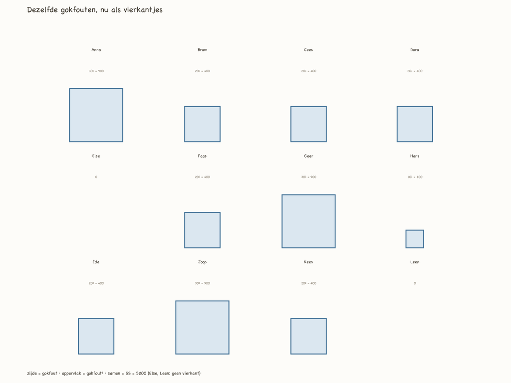

**Figuur 1.2** (vierkantjes) als warme boek-figuur; zelfde route. Else en Leen: geen vierkant (glans precies 50). Som van alle oppervlaktes = SS = 5200.

### Variantie

**variantie** *variance* notatie: $S^2$

We delen $SS$ niet door $n$, maar door $n-1$. Waarom?

Stel ik geef je drie envelopjes met geld, en zeg dat er gemiddeld 10 euro per envelopje in zit. Je opent de eerste (7 euro), de tweede (11 euro). Wat zit er in de derde? Niet *raden* — *uitrekenen*: drie envelopjes met gemiddelde 10 betekent totaal 30 euro. We hebben er 18 gezien, dus de derde bevat 12. De derde zit *vast* zodra je het gemiddelde weet en twee waarden hebt — er zijn maar 2 (dus $n-1$) écht vrij. Dat heet *vrijheidsgraden* (Engels: *degrees of freedom*, $df$).

Vertaald naar onze gokfouten: bij twaalf diamantjes met een bekend gemiddelde zijn er niet twaalf, maar elf échte gokfouten. De twaalfde ligt al vast — zodra je er elf weet, kun je de twaalfde uitrekenen, net als met die envelopjes.

Daarom delen we $SS$ door 11, niet door 12: door het aantal *écht vrije* gokfouten. Voel het zo en je hoeft niets te onthouden: variantie blijft *gemiddelde gekwadrateerde gokfout* — tel op, deel door aantal. Alleen ‘aantal’ is hier ‘aantal echte gokfouten’ — eentje minder dan je dacht. Eén gekke correctie, daar blijft het bij.

De formule, in twee notaties:

$$\begin{aligned}
S^2_X &= \frac{SS_X}{n-1} \\[0.4em]
&= \frac{\sum_{i=1}^{n} (X_i - \overline{X})^2}{n-1}
\end{aligned}
\tag{1.2a}$$

$$S^2_X = \frac{1}{n-1} \sum_{i=1}^{n} (X_i - \overline{X})^2 \tag{1.2b}$$

$$\begin{aligned}
S^2_X &= \frac{SS_X}{n-1} \\[0.4em]
&= \frac{1.68}{11} \\[0.4em]
&= 0.153
\end{aligned}$$

$$\begin{aligned}
S^2_Y &= \frac{SS_Y}{n-1} \\[0.4em]
&= \frac{5200}{11} \\[0.4em]
&= 472.7
\end{aligned}$$

Dit getal heet de *variantie*. Eenheid: karaat-kwadraten, glans-kwadraten. Vrij raar, want we hebben gekwadrateerd.

Variantie is dus nog niet de gemiddelde gokfout zelf. Het is de gemiddelde gekwadrateerde gokfout — een tussenstation, geen einddoel. Dat lossen we zo op.

Voor we de wortel pakken — kort moment van zelfreflectie. Zie je hoe vaak we het woord *gemiddelde* hebben gebruikt? Het gemiddelde van de waarden ($\overline{X}$). Het gemiddelde van de residuen (= 0). Het gemiddelde gekwadrateerde residu (de variantie). En straks de gemiddelde gokfout (de *SD*). Vier verschillende gemiddelden, telkens hetzelfde principe: tel iets op en deel door hoeveel. Het woord gaat je nog vaak achterna.

### Standaardafwijking — de gemiddelde gokfout

De *wortel* is de omgekeerde handeling van kwadrateren. Als $S^2 = 9$, dan is $S = \sqrt{9} = 3$. De wortel zoekt: welk positief getal moet ik kwadrateren om dit te krijgen?

Om van die rare kwadraat-eenheden af te komen, nemen we de wortel:

$$S_X = \sqrt{S^2_X} \tag{1.3}$$

$$\begin{aligned}
S_X &= \sqrt{S^2_X} \\[0.4em]
&= \sqrt{0.153} \\[0.4em]
&= 0.39
\end{aligned}$$

$$\begin{aligned}
S_Y &= \sqrt{S^2_Y} \\[0.4em]
&= \sqrt{472.7} \\[0.4em]
&= 21.74
\end{aligned}$$

**standaardafwijking** *standard deviation (SD)* notatie: $S$ ook: gemiddelde gokfout

*Standaardafwijking* is de mooie naam. Wat is het, intuïtief? Het is iets als de gemiddelde afstand van een diamant tot het gemiddelde diamantje, in dezelfde eenheid als de variabele zelf. Met een ander beeld: als je zou moeten gokken hoe ver een willekeurig diamantje van het gemiddelde af zit, en je nam de *SD* als je gok, dan zou je dichtbij zitten. Daarom noemen we het ook wel de *gemiddelde gokfout*. De olifant — die hier ergens nog steeds bij het meer staat — zou knikken: *dan weet je iets*.

Voor karaat: een gemiddelde gokfout van 0.39 karaat. Voor glans: een gemiddelde gokfout van 21.74 glanspunten.

Diezelfde *SD* is meteen je *lineaaltje*: het meetlatje waarmee je afmeet hoe ver een diamant van het gemiddelde ligt. Een diamant ver van het midden ligt er veel lineaaltjes vandaan, eentje vlakbij bijna geen — onthou dat woord, we gaan er nog vaak mee meten.

> *Het gemiddelde zegt wat je gokt; de standaardafwijking zegt hoe ver je er gemiddeld naast zit.*

In APA-rapportages, die je je hele studie nog tegenkomt, ziet dat er zo uit:

> *M* = 1.00, *SD* = 0.39 voor karaat. *M* = 50.00, *SD* = 21.74 voor glans.

Onthou die schrijfwijze. Hoofdletters cursief, twee decimalen, gescheiden met komma’s. We gaan dat de hele studie blijven zien.

### Eén blik op Kees

Een laatste gedachte. Kees: karaat 1.5 — dat is 0.5 boven het gemiddelde. Glans 30 — dat is 20 *onder* het gemiddelde. Kees is een grote maar doffe diamant. Statistisch gezien: zijn karaat-residu is positief en zijn glans-residu is negatief. Iets is daar niet helemaal in lijn.

Voor nu hoeft dat niets te betekenen. We hebben Kees alleen netjes opgemeten, samen met de elf anderen. Maar onthou hem — we komen op hem terug.

## 4. De wolk

We hebben nu een gemiddelde diamant en een gevoel voor hoe ver de andere ervan af staan. Voordat we sluiten, één blik op alle twaalf tegelijk — karaat op de ene as, glans op de andere, en de twee gemiddelden als gestreepte lijnen erdoorheen.

Puntenwolk-figuur H1 (karaat × glans, gemiddelde-lijnen, Else op het kruispunt): **gebouwd** als `h1_wolk.png` (warme stijl, `_bouw_decompositie.R`) en hieronder ingewired. De R-code staat als kiem in `03_oefenboek_kiemen/R_werk_uit_schetsen_2026-07-11.md`.

Wat zie je? Op het kruispunt van de twee gestreepte lijnen staat precies één punt: **Else** — de gemiddelde diamant in levenden lijve, zoals beloofd. Anna ligt linksonder, Geer rechtsboven, en Kees ligt rechtsónder, ver weg van de hoofdrichting. Dat valt zo op zonder dat we er iets over hebben verteld. Maar daar komen we in een later hoofdstuk uitgebreid op terug.

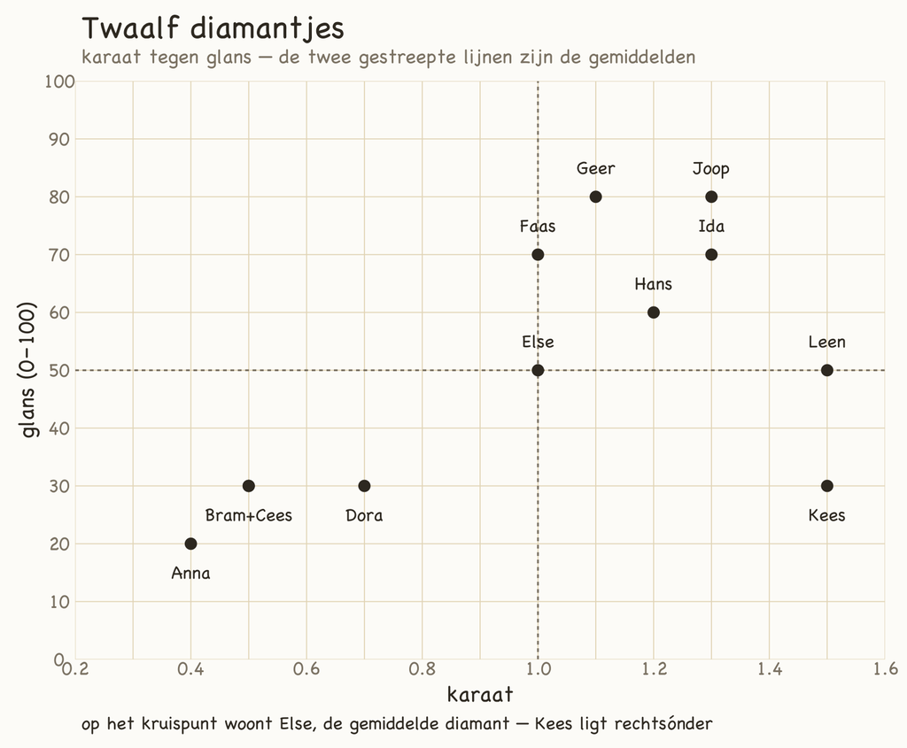

## 5. Sluiting

Goed.

We hebben nu een gemiddelde diamant — eentje van 1 karaat met een glans van 50 — en we weten ongeveer hoe ver de echte diamantjes daarvan af staan (de *SD*). De olifant zou knikken: er is een diamantje dat de andere dichtbij zijn, en je weet hoe ver “dichtbij” eigenlijk is.

Maar er is nog iets dat we kunnen voelen, als we naar de wolk kijken. De grote diamantjes glanzen meestal feller. De kleine zijn meestal doffer. Behalve Kees. Twee soorten verschil die een eind samen oplopen — een nieuwe vraag, een nieuw hoofdstuk.

Voor nu sluiten we. Het meer ligt nog steeds stil, en de olifant heeft alweer een slok.

## Open keuzes

- **Dam-regel is dragend geworden (5-7):** *“niet voor de eerste keer bleef er iets onverwachts in hangen — een tak, een vis, een schoen”* — H3 leunt hierop (de dam = vang-mechanisme, de vondst = steekproeftrekking). Bij de stem-pas níét wegpolijsten.
- **APA-tabel-styling**: in deze schets staat de data nog als plain markdown-tabel. Voor de uiteindelijke render kunnen we een R-chunk inbouwen met `kableExtra::kbl()` of `gt::gt()` + APA-conventies (geen verticale lijnen, alleen horizontale boven kop en onder body, cursieve kolomnamen). APA-conventies in lopende tekst staan al wél (cursieve *M* / *SD*, twee decimalen, komma’s).
- **Werktitel** — *De gemiddelde slok* leunt op de openingsscène. Alternatieven: *Wat het meer onthoudt*, *Een diamant die er niet is*, of nuchter *Gemiddelde en variantie*.
- ✅ **Vrijheidsgraden ($n-1$)** — afgevinkt 7-7 (sweep blok 0): de envelopjes-uitleg staat inmiddels volledig in §3; dit punt was stale.
- ✅ **Kees-case** — afgevinkt 7-7: geplant in §3-slot én geoogst in H4 (terugkeer-scène + onder-de-lijn); stale.
- ✅ **Werk-sectie → tabs (besloten 6-7):** JASP-tab vooraan, R-tab ernaast (eerste lezers = VIOS/GGZ-VS). **§4 ingedikt (6-7):** R-onboarding (installatie, .Rproj, script-discipline) verplaatst naar `03_oefenboek_kiemen/H1_R_onboarding.md` — kiem voor het R-oefenboek (*boek toont, oefenboek traint*). JASP-tab + screenshots bij de stem-pas. Zie keuzes.md §1.

Een boek in wording je leest mee terwijl het zijn vorm vindt